# Descriptive Statistics

Collins Audi

2025-09-26

**About the Dataset**: The Whitehall FoSSA Study is a simulated cohort study similar to the original Whitehall Study of Civil Servants, set up in the 1960s, which followed London-based male civil servants with a view to investigating cardiovascular disease and mortality. Participants from the original Whitehall cohort in the 1960s were flagged for mortality at the Office for National Statistics, which provided the date and cause of all deaths occurring until the end of September 2005. The (simulated) Whitehall FoSSA Study was conducted in 1997 to assess risk factors for cardiac and all-cause mortality in a subset of the original cohort that was still being followed. The Whitehall FoSSA Study contains information on 4,327 individuals that were followed-up from 1997 until 2005, and the variables are summarised in the table below. See Clarke et al. (2007), Arch Intern Med, 167(13) for more details on the real data that inspired this dataset.

```r
#Data Importation
whitehall <- read.csv("C:/Users/audic/Desktop/Fossa/module1/Whitehall_fossa.csv", header = TRUE, sep =',')
head(whitehall)
```

```
##   whl1_id age_grp prior_cvd prior_t2dm prior_cancer sbp bmi bmi_grp4 hdlc ldlc
## 1   10001       2         0          0            0 116  27        3 0.67 4.08
## 2   10002       4         0          0            0 115  25        3 0.97 3.51
## 3   10003       1         0          0            0 149  20        2 1.19 3.17
## 4   10004       3         0          0            0 139  21        2 1.58 2.52
## 5   10005       1         0          0            0 116  21        2 1.81 3.93
## 6   10006       3         0          0            0 149  26        3 0.77 2.80
##   chol currsmoker frailty     vitd cvd_death death fu_years
## 1 6.42          0       5 66.68633         1     1  5.63698
## 2 5.63          0       5 59.14547         0     1  1.14322
## 3 4.93          0       1 44.70118         0     0  8.50000
## 4 5.02          0       4 43.81604         0     0  8.50000
## 5 6.77          0       3 68.03349         0     1  6.18418
## 6 4.97          0       5 55.70111         1     1  4.60867
```

Data Checking: Commands used to inspect the structure and dimensions of the dataset

```r
#Data Checking
names(whitehall) #Column names
```

```
##  [1] "whl1_id"      "age_grp"      "prior_cvd"    "prior_t2dm"   "prior_cancer"
##  [6] "sbp"          "bmi"          "bmi_grp4"     "hdlc"         "ldlc"
## [11] "chol"         "currsmoker"   "frailty"      "vitd"         "cvd_death"
## [16] "death"        "fu_years"
```

```r
str(whitehall) #dataset structure
```

```
## 'data.frame':    4327 obs. of  17 variables:
##  $ whl1_id     : int  10001 10002 10003 10004 10005 10006 10007 10008 10009 10010 ...
##  $ age_grp     : int  2 4 1 3 1 3 2 2 2 1 ...
##  $ prior_cvd   : int  0 0 0 0 0 0 0 0 0 0 ...
##  $ prior_t2dm  : int  0 0 0 0 0 0 0 0 0 0 ...
##  $ prior_cancer: int  0 0 0 0 0 0 0 0 0 0 ...
##  $ sbp         : int  116 115 149 139 116 149 122 117 125 129 ...
##  $ bmi         : int  27 25 20 21 21 26 23 26 19 24 ...
##  $ bmi_grp4    : int  3 3 2 2 2 3 2 3 2 2 ...
##  $ hdlc        : num  0.67 0.97 1.19 1.58 1.81 ...
##  $ ldlc        : num  4.08 3.51 3.17 2.52 3.93 ...
##  $ chol        : num  6.42 5.63 4.93 5.02 6.77 ...
##  $ currsmoker  : int  0 0 0 0 0 0 0 0 0 0 ...
##  $ frailty     : int  5 5 1 4 3 5 1 2 5 1 ...
##  $ vitd        : num  66.7 59.1 44.7 43.8 68 ...
##  $ cvd_death   : int  1 0 0 0 0 1 0 0 0 0 ...
##  $ death       : int  1 1 0 0 1 1 0 0 0 0 ...
##  $ fu_years    : num  5.64 1.14 8.5 8.5 6.18 ...
```

```r
nrow(whitehall) #number of rows in the dataset
```

```
## [1] 4327
```

```r
ncol(whitehall) #number of columns in the dataset
```

```
## [1] 17
```

```r
dim(whitehall)
```

```
## [1] 4327   17
```

Current Smoker (currsmoker): Factor variable indicating whether a participant currently smokes.

Levels: No = 0 (non-smoker), Yes = 1 (current smoker)

```r
#Creating categories for smoking status
whitehall$currsmoker <- factor(whitehall$currsmoker, levels = 0:1, labels = c("No", "Yes"))
head(whitehall$currsmoker)
```

```
## [1] No No No No No No
## Levels: No Yes
```

```r
table(whitehall$bmi_grp4) #Creating a Table for BMI groups
```

```
##
##    1    2    3    4
##   50 1793 2091  376
```

```r
str(whitehall$bmi_grp4) #Inspecting structure of the dataset
```

```
##  int [1:4327] 3 3 2 2 2 3 2 3 2 2 ...
```

A new column was created to categorize participants based on BMI. Initially empty, it was filled with 0 for those with BMI below 30 and 1 for those with BMI 30 or above. This numeric coding was then converted into a factor with two categories, labeling participants as “Not obese” or “obese.”

```r
#Creating a new empty column
whitehall$bmi.2 <- whitehall$bmi

whitehall$bmi.2 <- NA

#Assigning 0 and 1 based ranges
whitehall$bmi.2[whitehall$bmi<30] <- 0
whitehall$bmi.2[whitehall$bmi>=30] <- 1

#Creating categories
whitehall$bmi.2 <- factor(whitehall$bmi.2, labels = c("Not obese","obese"))
head(whitehall$bmi.2)
```

```
## [1] Not obese Not obese Not obese Not obese Not obese Not obese
## Levels: Not obese obese
```

A new column was created to categorize LDL cholesterol levels, coding values ≤4 as 0 and values >4 as 1, then converting it into a factor with the categories “4 or below” and “above 4.”

```r
#Creating new empty column (low density lipoprotein cholesterol level)
whitehall$ldl2 <- whitehall$ldlc
whitehall$ldl2 <- NA

#Assigning codes to various ldl ranges
whitehall$ldl2[whitehall$ldlc<=4] <- 0
whitehall$ldl2[whitehall$ldlc>4] <- 1

#Creating categories
whitehall$ldl2 <- factor(whitehall$ldl2, labels = c("4 or below", "above 4"))
```

Descriptive statistics were calculated for the dataset to summarize key variables. Measures of central tendency and spread were obtained for continuous variables such as systolic blood pressure and cholesterol, including mean, median, mode, quartiles, interquartile range, minimum, maximum, and standard deviation. Variables were also inspected for their type and classification, identifying them as binary, continuous, or ordinal, and conversions to numeric were performed where necessary to facilitate analysis.

```r
#Descriptive Statistics
summary(whitehall)
```

```
##     whl1_id         age_grp        prior_cvd        prior_t2dm
##  Min.   :10001   Min.   :1.000   Min.   :0.0000   Min.   :0.00000
##  1st Qu.:11082   1st Qu.:2.000   1st Qu.:0.0000   1st Qu.:0.00000
##  Median :12164   Median :2.000   Median :0.0000   Median :0.00000
##  Mean   :12164   Mean   :2.328   Mean   :0.2491   Mean   :0.06009
##  3rd Qu.:13246   3rd Qu.:3.000   3rd Qu.:0.0000   3rd Qu.:0.00000
##  Max.   :14327   Max.   :4.000   Max.   :1.0000   Max.   :1.00000
##
##   prior_cancer         sbp             bmi           bmi_grp4
##  Min.   :0.0000   Min.   : 86.0   Min.   :15.00   Min.   :1.000
##  1st Qu.:0.0000   1st Qu.:119.0   1st Qu.:23.00   1st Qu.:2.000
##  Median :0.0000   Median :129.0   Median :25.00   Median :3.000
##  Mean   :0.0758   Mean   :130.8   Mean   :25.22   Mean   :2.648
##  3rd Qu.:0.0000   3rd Qu.:141.0   3rd Qu.:27.00   3rd Qu.:3.000
##  Max.   :1.0000   Max.   :230.0   Max.   :44.00   Max.   :4.000
##                   NA's   :9       NA's   :17      NA's   :17
##       hdlc            ldlc            chol       currsmoker     frailty
##  Min.   :0.050   Min.   :1.050   Min.   : 2.24   No  :3776   Min.   :1.00
##  1st Qu.:0.820   1st Qu.:2.840   1st Qu.: 4.85   Yes : 545   1st Qu.:2.00
##  Median :1.050   Median :3.350   Median : 5.47   NA's:   6   Median :3.00
##  Mean   :1.092   Mean   :3.367   Mean   : 5.51               Mean   :2.95
##  3rd Qu.:1.320   3rd Qu.:3.870   3rd Qu.: 6.15               3rd Qu.:4.00
##  Max.   :3.070   Max.   :6.810   Max.   :10.77               Max.   :5.00
##  NA's   :25      NA's   :25      NA's   :5
##       vitd          cvd_death          death           fu_years
##  Min.   : 18.92   Min.   :0.0000   Min.   :0.0000   Min.   :0.03117
##  1st Qu.: 45.60   1st Qu.:0.0000   1st Qu.:0.0000   1st Qu.:5.98514
##  Median : 55.70   Median :0.0000   Median :0.0000   Median :7.75754
##  Mean   : 57.39   Mean   :0.1514   Mean   :0.3527   Mean   :6.81234
##  3rd Qu.: 66.69   3rd Qu.:0.0000   3rd Qu.:1.0000   3rd Qu.:8.50000
##  Max.   :419.89   Max.   :1.0000   Max.   :1.0000   Max.   :8.50000
##
##        bmi.2              ldl2
##  Not obese:3934   4 or below:3441
##  obese    : 376   above 4   : 861
##  NA's     :  17   NA's      :  25
##
##
##
##
```

```r
by(whitehall, whitehall$age_grp, summary)
```

```
## whitehall$age_grp: 1
##     whl1_id         age_grp    prior_cvd        prior_t2dm
##  Min.   :10003   Min.   :1   Min.   :0.0000   Min.   :0.00000
##  1st Qu.:11013   1st Qu.:1   1st Qu.:0.0000   1st Qu.:0.00000
##  Median :12110   Median :1   Median :0.0000   Median :0.00000
##  Mean   :12138   Mean   :1   Mean   :0.2541   Mean   :0.04471
##  3rd Qu.:13252   3rd Qu.:1   3rd Qu.:1.0000   3rd Qu.:0.00000
##  Max.   :14323   Max.   :1   Max.   :1.0000   Max.   :1.00000
##
##   prior_cancer          sbp             bmi           bmi_grp4
##  Min.   :0.00000   Min.   : 87.0   Min.   :16.00   Min.   :1.00
##  1st Qu.:0.00000   1st Qu.:117.8   1st Qu.:23.00   1st Qu.:2.00
##  Median :0.00000   Median :128.5   Median :25.00   Median :3.00
##  Mean   :0.06824   Mean   :129.9   Mean   :25.34   Mean   :2.66
##  3rd Qu.:0.00000   3rd Qu.:140.0   3rd Qu.:27.00   3rd Qu.:3.00
##  Max.   :1.00000   Max.   :205.0   Max.   :41.00   Max.   :4.00
##                    NA's   :2       NA's   :6       NA's   :6
##       hdlc            ldlc            chol       currsmoker    frailty
##  Min.   :0.050   Min.   :1.150   Min.   :2.380   No :728    Min.   :1.00
##  1st Qu.:0.830   1st Qu.:2.880   1st Qu.:4.910   Yes:122    1st Qu.:1.00
##  Median :1.060   Median :3.340   Median :5.480              Median :2.00
##  Mean   :1.098   Mean   :3.368   Mean   :5.537              Mean   :2.42
##  3rd Qu.:1.320   3rd Qu.:3.850   3rd Qu.:6.150              3rd Qu.:4.00
##  Max.   :3.070   Max.   :6.530   Max.   :9.760              Max.   :5.00
##  NA's   :6       NA's   :5       NA's   :4
##       vitd          cvd_death           death           fu_years
##  Min.   : 22.20   Min.   :0.00000   Min.   :0.0000   Min.   :0.2745
##  1st Qu.: 50.40   1st Qu.:0.00000   1st Qu.:0.0000   1st Qu.:7.6138
##  Median : 60.34   Median :0.00000   Median :0.0000   Median :7.9062
##  Mean   : 61.72   Mean   :0.05529   Mean   :0.1612   Mean   :7.5706
##  3rd Qu.: 69.41   3rd Qu.:0.00000   3rd Qu.:0.0000   3rd Qu.:8.5000
##  Max.   :419.89   Max.   :1.00000   Max.   :1.0000   Max.   :8.5000
##
##        bmi.2             ldl2
##  Not obese:767   4 or below:678
##  obese    : 77   above 4   :167
##  NA's     :  6   NA's      :  5
##
##
##
```

[output cut: 112 more lines]

```
##  Min.   :0.0000   Min.   :0.0000   Min.   :0.06271   Not obese:540
##  1st Qu.:0.0000   1st Qu.:0.0000   1st Qu.:3.43643   obese    : 57
##  Median :0.0000   Median :1.0000   Median :6.03797
##  Mean   :0.3132   Mean   :0.6901   Mean   :5.51926
##  3rd Qu.:1.0000   3rd Qu.:1.0000   3rd Qu.:7.81324
##  Max.   :1.0000   Max.   :1.0000   Max.   :8.50000
##
##          ldl2
##  4 or below:468
##  above 4   :127
##  NA's      :  2
##
##
##
##
```

```r
mean1 <- mean(as.numeric(whitehall$sbp), na.rm = TRUE)
mean1
```

```
## [1] 130.7515
```

```r
median1 <- median(as.numeric(whitehall$sbp), na.rm = TRUE)
median1
```

```
## [1] 129
```

```r
#First and Third QUartile
first_tquat <- quantile(as.numeric(whitehall$sbp), probs=0.25, na.rm=TRUE)
first_tquat
```

```
## 25%
## 119
```

```r
third_tquat <- quantile(as.numeric(whitehall$sbp), probs=0.75, na.rm=TRUE)
third_tquat
```

```
## 75%
## 141
```

```r
#Interquartile Range
IQR = third_tquat - first_tquat

whitehall$sbp <- as.numeric(whitehall$sbp)
IQR(whitehall$sbp, na.rm = TRUE)
```

```
## [1] 22
```

```r
class(whitehall$sbp)
```

```
## [1] "numeric"
```

```r
stats::IQR(whitehall$sbp, na.rm = TRUE)
```

```
## [1] 22
```

```r
#Variable Class
class(whitehall$prior_cvd)   #numeric
```

```
## [1] "integer"
```

```r
class(whitehall$sbp)         #numeric
```

```
## [1] "numeric"
```

```r
class(whitehall$frailty)    #numeric
```

```
## [1] "integer"
```

```r
class(whitehall$death)      #numeric
```

```
## [1] "integer"
```

```r
#Converting the class for cholesterol to numeric
whitehall$chol <- as.numeric(whitehall$chol)

#DescTools for Mode
library(DescTools)
Mode(whitehall$chol, na.rm=TRUE)
```

```
## [1] 5.07
## attr(,"freq")
## [1] 35
```

```r
#Maximym and Minimum values
max(whitehall$chol, na.rm=TRUE)
```

```
## [1] 10.77
```

```r
min(whitehall$chol, na.rm=TRUE)
```

```
## [1] 2.24
```

```r
#Standard Deviation
sd(whitehall$chol, na.rm=TRUE)
```

```
## [1] 1.00712
```

Visualizations were created to explore the distribution of key variables in the dataset. BMI was represented using both bar plots and histograms to show the number of participants across individual values and grouped categories, with color gradients enhancing visual distinction. BMI was also grouped into standard categories, and a corresponding bar plot highlighted the frequency of participants in each BMI range. Similarly, systolic blood pressure (SBP) was categorized into clinical groups, from normotensive to stage 2 hypertension, and visualized with histograms to examine its distribution. Different bin widths were used in SBP histograms to provide both detailed and broader views of the data. Overall, these plots allow a clear visual summary of participant characteristics and the spread of measurements.

```r
library(tidyverse)
```

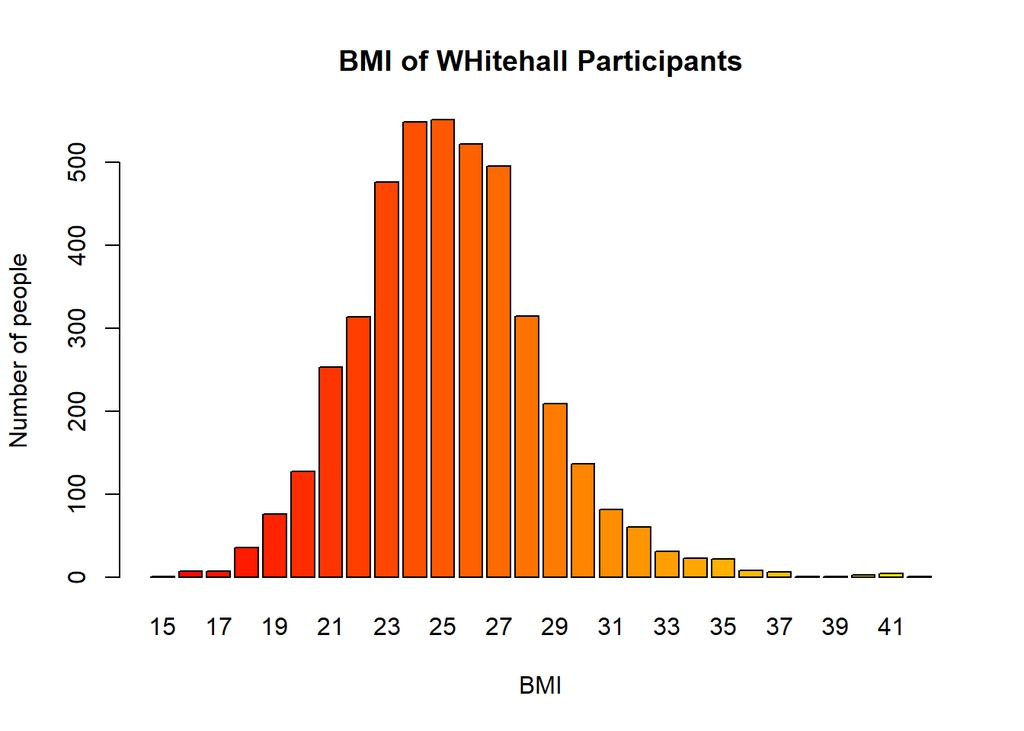

```r
library(RColorBrewer)

bmi.counts <- table(whitehall$bmi)

whitehall$bmi <- as.numeric(whitehall$bmi)

#BMI Bar Plot

barplot(bmi.counts, xlab = "BMI", ylab = "Number of people", main = "BMI of WHitehall Participants", col=heat.colors(40))
```

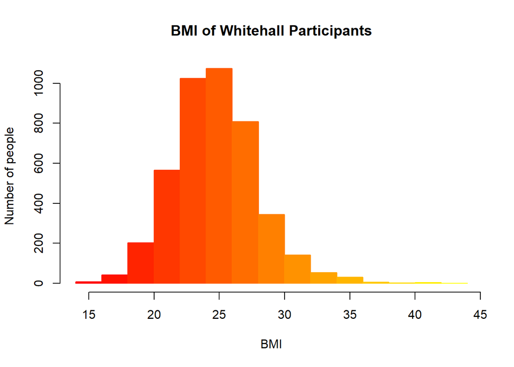

```r
hist(whitehall$bmi, xlab ="BMI", ylab = "Number of people", main = "BMI of Whitehall Participants", col=heat.colors(20), density=150)
```

```r
#Creating a new empty BMI Column
whitehall$bmi.grouped <- NA

#Grouping Body Mass Index
whitehall$bmi.grouped [whitehall$bmi<18.5] <- 0
whitehall$bmi.grouped[whitehall$bmi>=18.5 & whitehall$bmi<25] <- 1
whitehall$bmi.grouped[whitehall$bmi>=25 & whitehall$bmi<30] <-2
whitehall$bmi.grouped [whitehall$bmi>=30] <-3

class(whitehall$bmi.grouped)
```

```
## [1] "numeric"
```

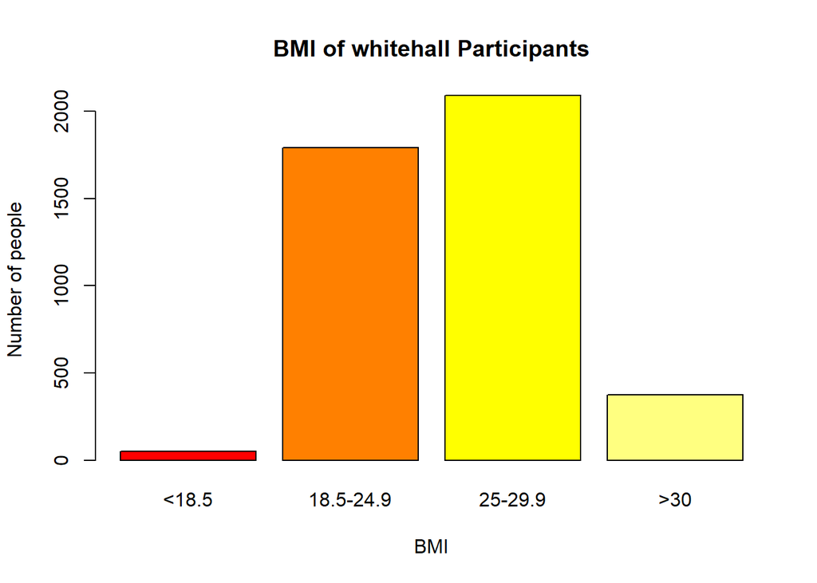

```r
#Creating Categories
whitehall$bmi.grouped <- factor (whitehall$bmi.grouped, levels = 0:3, labels=c("<18.5", "18.5-24.9", "25-29.9", ">30"))

bmi.grouped.graph <- table(whitehall$bmi.grouped)
barplot (bmi.grouped.graph, horiz = FALSE, xlab = "BMI", ylab = "Number of people", main = "BMI of whitehall Participants", col=heat.colors(4))
```

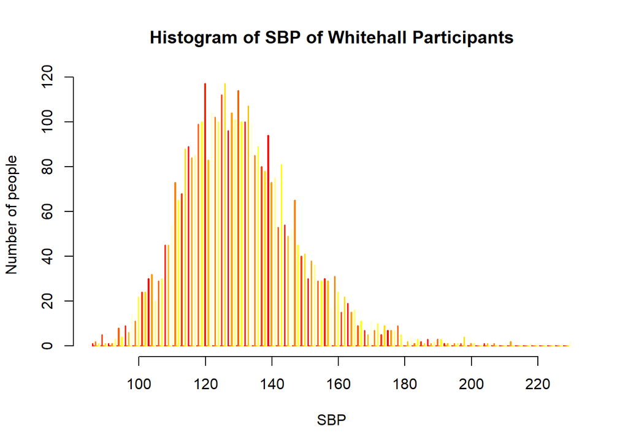

```r
#Creating a new empty column
whitehall$sbp.grouped <- NA

#Grouping sbp
whitehall$sbp.grouped[whitehall$sbp<120] <- 1
whitehall$sbp.grouped[whitehall$sbp>=120 & whitehall$sbp<130] <-2
whitehall$sbp.grouped[whitehall$sbp>=130 & whitehall$sbp<140] <-3
whitehall$sbp.grouped[whitehall$sbp>=140] <- 4

#Creating hypertension categories
whitehall$sbp.grouped <- factor(whitehall$sbp.grouped, levels = 1:4, labels=c("Normotensive", "Elevated", "Stage 1 Hypertension", "Stage 2 Hypertension"))

#Plotting a histogram of systolic blood pressure
hist(whitehall$sbp, xlab = "SBP", ylab = "Number of people", main = "Histogram of SBP of Whitehall Participants", col=heat.colors(12), density=100, breaks = 1000)
```

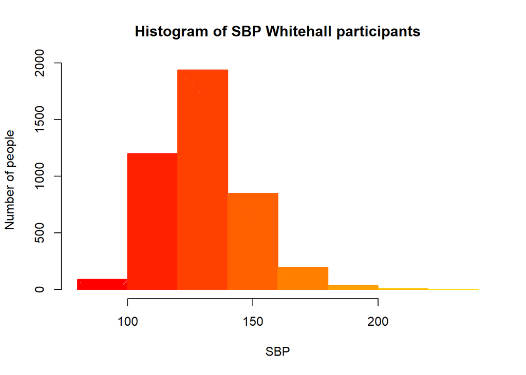

```r
#Plotting histogram of systolic blood pressure with larger bins
hist(whitehall$sbp, xlab = "SBP", ylab = "Number of people", main = "Histogram of SBP Whitehall participants", col=heat.colors(12), density=100, breaks = 10)
```

Calculation of standard errors, standard devistions and confidence intervals

```r
#Standard Deviation
sbp.n <- sum(!is.na(whitehall$sbp))
sbp.sd <- sd(as.numeric(whitehall$sbp), na.rm=TRUE)
sbp.sd
```

```
## [1] 17.56559
```

```r
whitehall$sbp <- as.numeric(whitehall$sbp)

#Standard Error of Sampling Statistics
sbp.se <- sbp.sd/sqrt(sbp.n)

round (sbp.se, 3)
```

```
## [1] 0.267
```

```r
Za <- qnorm (0.975)

sbp.mean <- mean(whitehall$sbp, na.rm=TRUE)
sbp.mean
```

```
## [1] 130.7515
```

```r
ci.Z_SBP <- c(sbp.mean - (sbp.sd/sqrt(sbp.n)*Za), sbp.mean + (sbp.sd/sqrt(sbp.n)*Za))

ci.Z_SBP
```

```
## [1] 130.2276 131.2754
```

```r
Za <- qnorm (0.975)

BMI.n <- sum(!is.na(whitehall$bmi))

whitehall$bmi <- as.numeric(whitehall$bmi)

BMI.sd <- sd(whitehall$bmi, na.rm = T )

BMI.mean <- mean(whitehall$bmi, na.rm = T)

ci.Z_BMI <- c(BMI.mean - (BMI.sd/sqrt(BMI.n)*Za), BMI.mean + (BMI.sd/sqrt(BMI.n)*Za))

ci.Z_BMI
```

```
## [1] 25.11954 25.31434
```

```r
#99% CI for BMI
Za <- qnorm (0.995)

BMI.n <- sum(!is.na(whitehall$bmi))

BMI.sd <- sd(whitehall$bmi, na.rm = T )

BMI.mean <- mean(whitehall$bmi, na.rm = T)

ci.Z_BMI <- c(BMI.mean - (BMI.sd/sqrt(BMI.n)*Za), BMI.mean + (BMI.sd/sqrt(BMI.n)*Za))

ci.Z_BMI
```

```
## [1] 25.08894 25.34494
```